# Central limit theorem of martingale difference sequence

# Central limit theorem

In this short note, we illustrate the central limit theorem (CLT) for i.i.d. random variables as well as for martingale difference sequences (m.d.s.). To do so, we will use the same code as the one for generating stochastic processes.

In this exercise, we shall do the following:

1. Simulate from different stochastic processes.
2. Check the central limit theorems.

We start by a simple stochastic process that consists in i.i.d. random variables that are distributed according to a student distribution. Since each random variables in the SP exhibits the same distribution and is independent from the other random variables in the sequence, the CLT for i.i.d. random variables applies (if the variance exists). Therefore, the average times $\sqrt{T}$ should be distributed according to a Normal distribution. In particular, we should have
$$\sqrt{T} \bar{X} \rightarrow_d N(E(X),V(X)).$$
For a student distribution with $\nu$ degrees of freedom, the variance is given by
$$V(X) = \frac{\nu}{\nu-2} ~~\text{for } \nu>2.$$
So, for large sample size, we should have that
$$\sqrt{T} \bar{X} \rightarrow_d N(0,\frac{\nu}{\nu-2}) ~~\text{for } \nu>2.$$

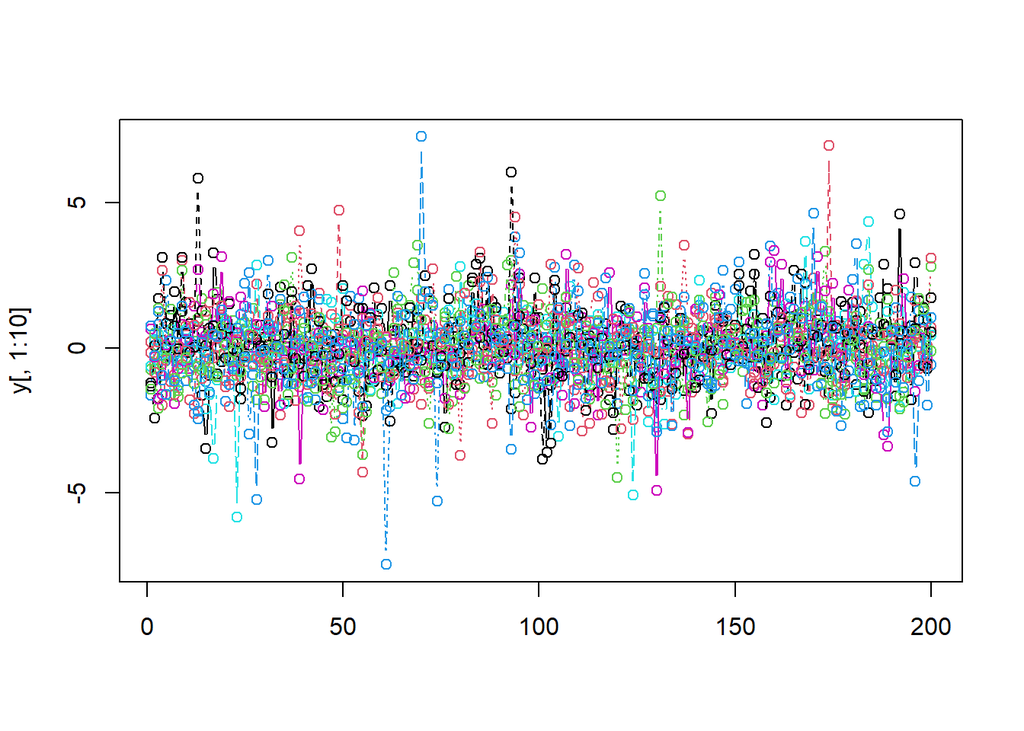

```r
## i.i.d.
T = 200 ## length of one path of the SP
nb_replic = 10000 ## Number of replications (number of draws from the SP)
y = array(0,dim=c(T,nb_replic))

df = 5
for(i in 1:nb_replic){
  y[,i] = rt(T,df)
}
matplot(y[,1:10],type = c("b"),pch=1) ## Check several paths of the SP (stationary or not stationary ?)
```

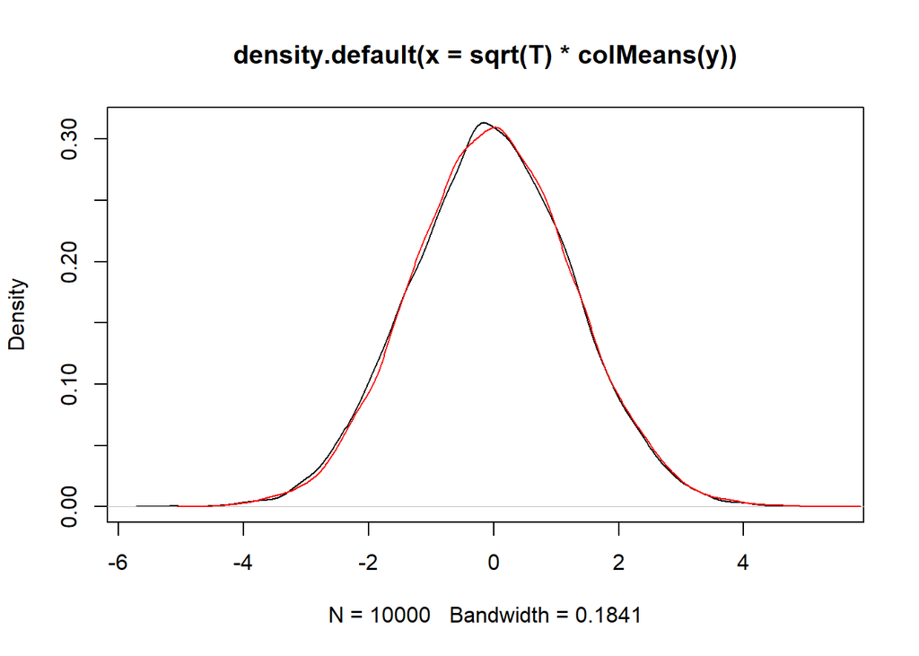

```r
plot(density(sqrt(T)*colMeans(y)))
lines(density(rnorm(10000)*sqrt(df/(df-2))),col = 'red')
```

We now consider martingale difference sequences specified as
$$y_t = \sqrt{\omega + \alpha y_{t-1}^2} \epsilon_t ~~\text{ where } \epsilon_t \sim N(0,1).$$
In such a case, we will show in the course on volatility models that $V(y_t) = \frac{\omega}{1-\alpha}$ if $\alpha<1$ and $\alpha>0$. The expectation of $y_t$ is simply
$$E(y_t) = E(E(y_t|y_{t-1})) = E(\sqrt{\omega + \alpha y_{t-1}^2}E(\epsilon_t|y_{t-1})) = 0.$$
According to the CLT on m.d.s., we should have that
$$\sqrt{T} \bar{Y} \rightarrow_d N(0,\frac{\omega}{1-\alpha}) ~~\text{for large T}.$$

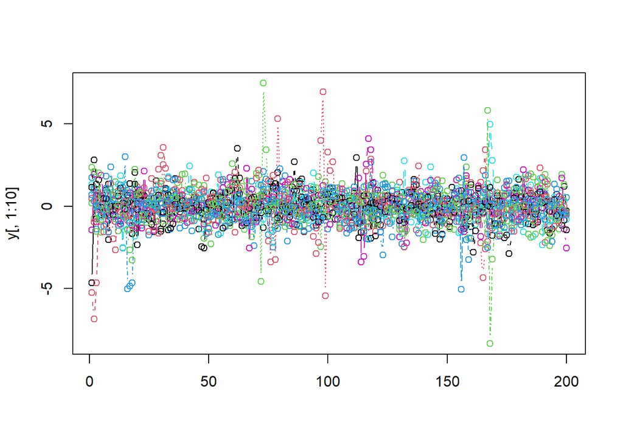

```r
## m.d.s.
T = 200
nb_replic = 10000
y = array(0,dim=c(T,nb_replic))

omega = 0.5
alpha = 0.5
for(i in 1:nb_replic){
  y[1,i] = rnorm(1)*sqrt(4)
  for(t in 2:T){
    y[t,i] = rnorm(1)*sqrt(omega + alpha*y[t-1,i]^2)
  }

}
matplot(y[,1:10],type = c("b"),pch=1)
```

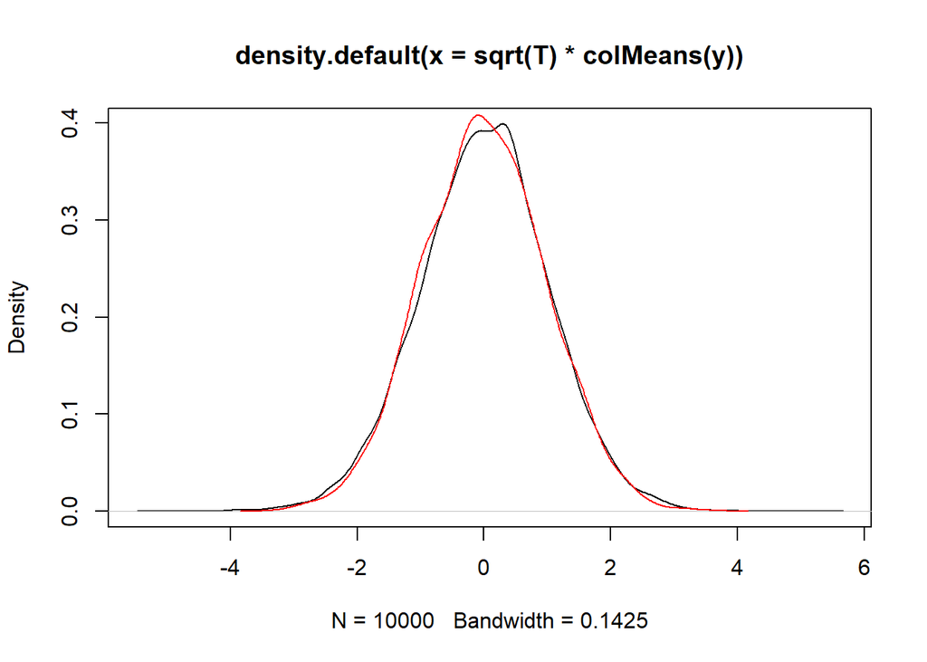

```r
plot(density(sqrt(T)*colMeans(y)))
lines(density(rnorm(10000)*sqrt(omega/(1-alpha))),col = 'red')
```